# Synergy assesment

Itziar Irurzun Arana

2019-07-25

In order to quantify the degree of synergy/antagonism between two compounds, the typical approach is to compare their measured combination effect to a null reference model of no interaction, i.e. the expected response assuming no interaction between the two compounds. If the combination response is greater than what is expected by the reference model, the combination is classified as synergistic, while antagonism is defined when the combination produces less than the expected effect.

There are several well-known conventional approaches that define different null models to assess drug synergy/antagonism. In this example, we will compare the drug-concentration dependent birth rates that can be obtained from the analysis of cell vialibility and apoptosis assay data, to the birth rates obtained under two common no-interaction models: Loewe additivity and Highest Single Agent.

Load libraries:

```r
library(ACESO)
```

## Data

In the current evaluation, cell viability data resulting from the exposure of BT-20 triple-negative breast cancer cell line to the combination of different concentrations of two small molecule kinase inhibitors (dactolisib and trametinib) is analyzed. The data was obtained from the HMS LINCS database (). The objective of this vignette is to analyze the possible synergism that arises from the combination of the drugs. The birth and death rate have been already calculated using this data and functions from ACESO package.

```r
data(Dactolisib_Trametinib_rates)
head(GD)
```

```
#>    Cell.line CONC   CONC2  Net_growth Type Birth_rate Death_rate
#> 1      BT-20    0  0.0000 0.007727910    0 0.02872791      0.021
#> 4      BT-20    0  0.1235 0.005032087    0 0.02603209      0.021
#> 7      BT-20    0  0.3704 0.005433627    0 0.02643363      0.021
#> 10     BT-20    0  1.1111 0.003351660    0 0.02435166      0.021
#> 13     BT-20    0  3.3333 0.003391692    0 0.02439169      0.021
#> 16     BT-20    0 10.0000 0.002139690    0 0.02313969      0.021
#>     Drug.Name Drug2.Name
#> 1  Dactolisib Trametinib
#> 4  Dactolisib Trametinib
#> 7  Dactolisib Trametinib
#> 10 Dactolisib Trametinib
#> 13 Dactolisib Trametinib
#> 16 Dactolisib Trametinib
```

```r
DrugA=as.character(GD$Drug.Name[1])
DrugB=as.character(GD$Drug2.Name[1])
print(c(DrugA,DrugB))
```

```
#> [1] "Dactolisib" "Trametinib"
```

Use **responseMap** function to plot the surface of the birth rate values versus both drug concentrations:

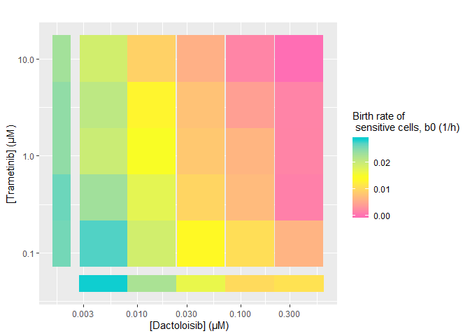

```r
rmap <- responseMap(Birth_rate~CONC+CONC2,GD,logscale=T,interpolate=FALSE)
DifferenceSurface.plot(rmap,zcenter=max(GD$Birth_rate)/2,
                       xl=" [Dactoloisib] (µM)",
                       yl="[Trametinib] (µM)",
                       zl="Birth rate of \n sensitive cells, b0 (1/h)",
                       mid="yellow",low="hotpink1",high="darkturquoise")
```

Use **responseMap** again and **plot.ResponseSurface** to make a contour plot of the data. For this plot a interpolation of the data is needed (see logscale=T in the **responseMap** function):

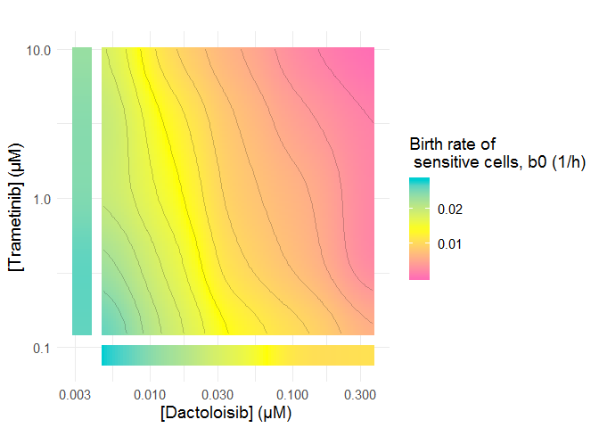

```r
rmap <- responseMap(Birth_rate~CONC+CONC2,GD,logscale=T)

ResponseSurface.plot(rmap,xl=" [Dactoloisib] (µM)",
                     yl="[Trametinib] (µM)",
                     zl="Birth rate of \n sensitive cells, b0 (1/h)",
                     palette=c("hotpink1","yellow","darkturquoise"))
```

## Loewe additivity

Loewe additivity model defines synergy/antagonism as a combined inhibitory effect that is greater/lower than the sum of the individual effects of the drugs. The null reference model in this case is the sum of the individual effect of each drug, which is calculated from the sigmoidal fits of the single-agent response curves. To automatically perform this task the **Loewe** function can be used:

```r
GD=Loewe(data=GD,resp = 'Birth_rate')
```

A new column called ‘loewe_addivity’ is created. Now we plot the response surface of the data using the newly created column to compare it with the previous response surface for the birth rates of sensitive cell population.

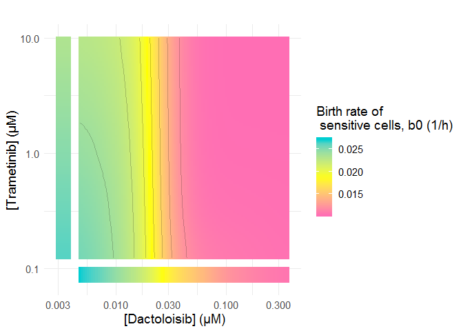

```r
rmap_loewe <- responseMap(loewe_additivity~CONC+CONC2,GD,logscale=T)

ResponseSurface.plot(rmap_loewe,xl=" [Dactoloisib] (µM)",
                     yl="[Trametinib] (µM)",
                     zl="Birth rate of \n sensitive cells, b0 (1/h)",
                     palette=c("hotpink1","yellow","darkturquoise"))
```

For a proper comparison of the surfaces, we calculate the difference between them and plot the results in a colored pairwise matrix. The score showed in this matrices reflects the difference between the measurement and the surface obtained under the no interaction models in a way that values less than zero (blue) represent antagonism and values greater that zero (yellow) represent synergism.

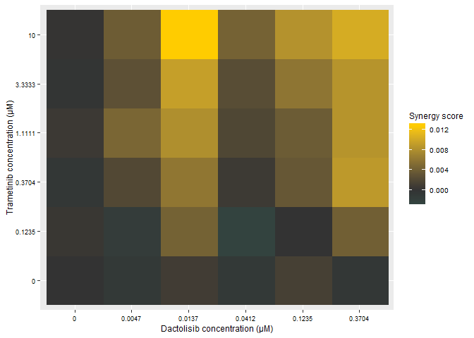

```r
GD$diffLoewe=(GD$loewe_additivity-GD$Birth_rate)

p=SynergyMatrix.plot(GD,resp="diffLoewe")
p+ggplot2::labs(x="Dactolisib concentration (µM)", y="Trametinib concentration (µM)")
```

## Highest Single Agent (HSA)

Now, we are going to repeat the process using the Highest Single Agent (HSA) model. HSA, also known as Gaddum’s non-interaction model, is another popular model which defines a independent action of the drugs when the predicted effect of a combination is that of the one most effective drug alone. To calculate the null surface of the HSA model, use **HSA** function:

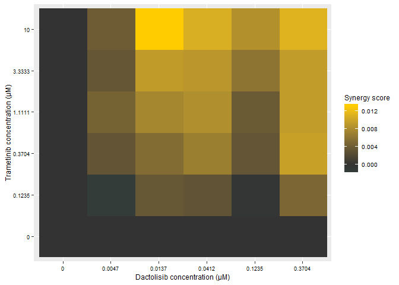

```r
GD=HSA(GD,resp = 'Birth_rate')

GD$diffHSA=(GD$HSA_response-GD$Birth_rate)

p2=SynergyMatrix.plot(GD,resp="diffHSA")
p2+ggplot2::labs(x="Dactolisib concentration (µM)", y="Trametinib concentration (µM)")
```